# WindPowerGeneration

Aleksander Dominas

05/01/2024

# Importing libraries

```r
library(ggplot2)
library(grid)
library(gridExtra)
library(stringr)
library(dplyr)
library(corrplot)
```

# Loading the data

Setting working directory and loading the data

```r
setwd("C:/Users/aleks/OneDrive/Documents/flutter_projects/power_generation_data")
```

```r
location1 <- read.csv("Location1.csv")
location2 <- read.csv("Location2.csv")
location3 <- read.csv("Location3.csv")
location4 <- read.csv("Location4.csv")
```

# Exploring the data

```r
summary(location1)
```

```
##      Time           temperature_2m   relativehumidity_2m  dewpoint_2m
##  Length:43800       Min.   :-14.40   Min.   : 18.00      Min.   :-17.10
##  Class :character   1st Qu.: 32.10   1st Qu.: 60.00      1st Qu.: 24.30
##  Mode  :character   Median : 47.30   Median : 74.00      Median : 38.10
##                     Mean   : 47.86   Mean   : 72.29      Mean   : 38.57
##                     3rd Qu.: 64.50   3rd Qu.: 86.00      3rd Qu.: 54.70
##                     Max.   : 94.10   Max.   :100.00      Max.   : 76.30
##  windspeed_10m    windspeed_100m   winddirection_10m winddirection_100m
##  Min.   : 0.000   Min.   : 0.100   Min.   :  1.0     Min.   :  0.0
##  1st Qu.: 2.410   1st Qu.: 4.380   1st Qu.:132.0     1st Qu.:130.0
##  Median : 3.300   Median : 6.080   Median :225.0     Median :226.0
##  Mean   : 3.591   Mean   : 6.284   Mean   :203.6     Mean   :203.3
##  3rd Qu.: 4.590   3rd Qu.: 7.990   3rd Qu.:277.0     3rd Qu.:278.0
##  Max.   :13.450   Max.   :20.650   Max.   :360.0     Max.   :360.0
##  windgusts_10m        Power
##  Min.   : 0.500   Min.   :0.0000
##  1st Qu.: 5.000   1st Qu.:0.1489
##  Median : 7.200   Median :0.3477
##  Mean   : 7.772   Mean   :0.4054
##  3rd Qu.:10.000   3rd Qu.:0.6596
##  Max.   :29.200   Max.   :0.9913
```

```r
head(location1)
```

```
##                  Time temperature_2m relativehumidity_2m dewpoint_2m
## 1 2017-01-02 00:00:00           28.5                  85        24.5
## 2 2017-01-02 01:00:00           28.4                  86        24.7
## 3 2017-01-02 02:00:00           26.8                  91        24.5
## 4 2017-01-02 03:00:00           27.4                  88        24.3
## 5 2017-01-02 04:00:00           27.3                  88        24.1
## 6 2017-01-02 05:00:00           27.6                  90        25.2
##   windspeed_10m windspeed_100m winddirection_10m winddirection_100m
## 1          1.44           1.26               146                162
## 2          2.06           3.99               151                158
## 3          1.30           2.78               148                150
## 4          1.30           2.69                58                105
## 5          2.47           4.43                58                 84
## 6          2.73           5.59                66                 80
##   windgusts_10m  Power
## 1           1.4 0.1635
## 2           4.4 0.1424
## 3           3.2 0.1214
## 4           1.6 0.1003
## 5           4.0 0.0793
## 6           4.5 0.0778
```

All variable types look correctly categorised.

Checking for NAs by column:

```r
colSums(is.na(location1))
```

```
##                Time      temperature_2m relativehumidity_2m         dewpoint_2m
##                   0                   0                   0                   0
##       windspeed_10m      windspeed_100m   winddirection_10m  winddirection_100m
##                   0                   0                   0                   0
##       windgusts_10m               Power
##                   0                   0
```

```r
colSums(is.na(location2))
```

```
##                Time      temperature_2m relativehumidity_2m         dewpoint_2m
##                   0                   0                   0                   0
##       windspeed_10m      windspeed_100m   winddirection_10m  winddirection_100m
##                   0                   0                   0                   0
##       windgusts_10m               Power
##                   0                   0
```

```r
colSums(is.na(location3))
```

```
##                Time      temperature_2m relativehumidity_2m         dewpoint_2m
##                   0                   0                   0                   0
##       windspeed_10m      windspeed_100m   winddirection_10m  winddirection_100m
##                   0                   0                   0                   0
##       windgusts_10m               Power
##                   0                   0
```

```r
colSums(is.na(location4))
```

```
##                Time      temperature_2m relativehumidity_2m         dewpoint_2m
##                   0                   0                   0                   0
##       windspeed_10m      windspeed_100m   winddirection_10m  winddirection_100m
##                   0                   0                   0                   0
##       windgusts_10m               Power
##                   0                   0
```

# Cleaning/transforming the data

As mentioned in the Readme of the Kaggle dataset, wind direction is given in degrees from 0-360. 0 and 360 indicate the same point on the circle, so it would be best to:

1. Convert the degrees to radians
2. Transform using sine or cosine

This would convert the circular data into two-dimensional Cartesian coordinates, capturing the circular nature of the data, allowing for more accurate statistical modeling and analysis.

```r
# Convert degrees to radians
wind_direction_10_loc1_radians <- location1$winddirection_10m * (pi / 180)
wind_direction_100_loc1_radians <- location1$winddirection_100m * (pi / 180)

wind_direction_10_loc2_radians <- location2$winddirection_10m * (pi / 180)
wind_direction_100_loc2_radians <- location2$winddirection_100m * (pi / 180)

wind_direction_10_loc3_radians <- location3$winddirection_10m * (pi / 180)
wind_direction_100_loc3_radians <- location3$winddirection_100m * (pi / 180)

wind_direction_10_loc4_radians <- location4$winddirection_10m * (pi / 180)
wind_direction_100_loc4_radians <- location4$winddirection_100m * (pi / 180)

# Sine transformations
sin_wd_10_loc1 <- sin(wind_direction_10_loc1_radians)
sin_wd_100_loc1 <- sin(wind_direction_100_loc1_radians)

sin_wd_10_loc2 <- sin(wind_direction_10_loc2_radians)
sin_wd_100_loc2 <- sin(wind_direction_100_loc2_radians)

sin_wd_10_loc3 <- sin(wind_direction_10_loc3_radians)
sin_wd_100_loc3 <- sin(wind_direction_100_loc3_radians)

sin_wd_10_loc4 <- sin(wind_direction_10_loc4_radians)
sin_wd_100_loc4 <- sin(wind_direction_100_loc4_radians)

# Adding columns to dataframes
location1$sin_wd_10 <- sin_wd_10_loc1
location1$sin_wd_100 <- sin_wd_100_loc1

location2$sin_wd_10 <- sin_wd_10_loc2
location2$sin_wd_100 <- sin_wd_100_loc2

location3$sin_wd_10 <- sin_wd_10_loc3
location3$sin_wd_100 <- sin_wd_100_loc3

location4$sin_wd_10 <- sin_wd_10_loc4
location4$sin_wd_100 <- sin_wd_100_loc4
```

```r
head(location1)
```

```
##                  Time temperature_2m relativehumidity_2m dewpoint_2m
## 1 2017-01-02 00:00:00           28.5                  85        24.5
## 2 2017-01-02 01:00:00           28.4                  86        24.7
## 3 2017-01-02 02:00:00           26.8                  91        24.5
## 4 2017-01-02 03:00:00           27.4                  88        24.3
## 5 2017-01-02 04:00:00           27.3                  88        24.1
## 6 2017-01-02 05:00:00           27.6                  90        25.2
##   windspeed_10m windspeed_100m winddirection_10m winddirection_100m
## 1          1.44           1.26               146                162
## 2          2.06           3.99               151                158
## 3          1.30           2.78               148                150
## 4          1.30           2.69                58                105
## 5          2.47           4.43                58                 84
## 6          2.73           5.59                66                 80
##   windgusts_10m  Power sin_wd_10 sin_wd_100
## 1           1.4 0.1635 0.5591929  0.3090170
## 2           4.4 0.1424 0.4848096  0.3746066
## 3           3.2 0.1214 0.5299193  0.5000000
## 4           1.6 0.1003 0.8480481  0.9659258
## 5           4.0 0.0793 0.8480481  0.9945219
## 6           4.5 0.0778 0.9135455  0.9848078
```

```r
head(location2)
```

```
##                  Time temperature_2m relativehumidity_2m dewpoint_2m
## 1 2017-01-02 00:00:00           14.5                  91        12.4
## 2 2017-01-02 01:00:00           14.5                  92        12.7
## 3 2017-01-02 02:00:00           14.7                  92        12.7
## 4 2017-01-02 03:00:00           14.7                  92        12.8
## 5 2017-01-02 04:00:00           14.8                  92        12.9
## 6 2017-01-02 05:00:00           14.7                  92        12.9
##   windspeed_10m windspeed_100m winddirection_10m winddirection_100m
## 1          6.37           9.58                68                 72
## 2          6.46           9.23                68                 72
## 3          6.18           9.27                67                 74
## 4          5.91           9.08                62                 69
## 5          5.88           8.72                58                 65
## 6          6.12           8.83                52                 59
##   windgusts_10m  Power sin_wd_10 sin_wd_100
## 1           9.9 0.2574 0.9271839  0.9510565
## 2           9.5 0.2535 0.9271839  0.9510565
## 3           9.4 0.2497 0.9205049  0.9612617
## 4           9.1 0.2458 0.8829476  0.9335804
## 5           8.7 0.2419 0.8480481  0.9063078
## 6           8.8 0.2354 0.7880108  0.8571673
```

```r
head(location3)
```

```
##                  Time temperature_2m relativehumidity_2m dewpoint_2m
## 1 2017-01-02 00:00:00           29.7                  55        15.4
## 2 2017-01-02 01:00:00           29.6                  56        15.6
## 3 2017-01-02 02:00:00           29.8                  56        16.1
## 4 2017-01-02 03:00:00           29.8                  58        16.8
## 5 2017-01-02 04:00:00           30.2                  59        17.8
## 6 2017-01-02 05:00:00           30.1                  68        20.9
##   windspeed_10m windspeed_100m winddirection_10m winddirection_100m
## 1          4.96           8.46               124                129
## 2          4.97           8.43               120                124
## 3          5.69           9.18               121                123
## 4          5.49           8.88               123                126
## 5          5.19           8.36               124                127
## 6          4.75           7.55               120                125
##   windgusts_10m  Power sin_wd_10 sin_wd_100
## 1           8.8 0.3438 0.8290376  0.7771460
## 2           8.5 0.3954 0.8660254  0.8290376
## 3           9.7 0.4471 0.8571673  0.8386706
## 4           9.9 0.4988 0.8386706  0.8090170
## 5           9.4 0.5504 0.8290376  0.7986355
## 6           8.9 0.5731 0.8660254  0.8191520
```

```r
head(location4)
```

```
##                  Time temperature_2m relativehumidity_2m dewpoint_2m
## 1 2017-01-02 00:00:00           22.7                  82        18.0
## 2 2017-01-02 01:00:00           22.0                  82        17.4
## 3 2017-01-02 02:00:00           21.7                  82        17.1
## 4 2017-01-02 03:00:00           21.7                  85        17.8
## 5 2017-01-02 04:00:00           22.4                  88        19.5
## 6 2017-01-02 05:00:00           22.8                  90        20.4
##   windspeed_10m windspeed_100m winddirection_10m winddirection_100m
## 1          3.21           7.60                86                 90
## 2          3.40           7.92                88                 94
## 3          3.81           8.41                87                 93
## 4          3.70           8.26                90                 97
## 5          3.85           8.50                81                 91
## 6          3.59           8.12                77                 86
##   windgusts_10m  Power sin_wd_10 sin_wd_100
## 1           5.3 0.3047 0.9975641  1.0000000
## 2           5.7 0.3516 0.9993908  0.9975641
## 3           6.4 0.3985 0.9986295  0.9986295
## 4           6.4 0.4454 1.0000000  0.9925462
## 5           6.6 0.4922 0.9876883  0.9998477
## 6           6.5 0.4900 0.9743701  0.9975641
```

# Exploring the data

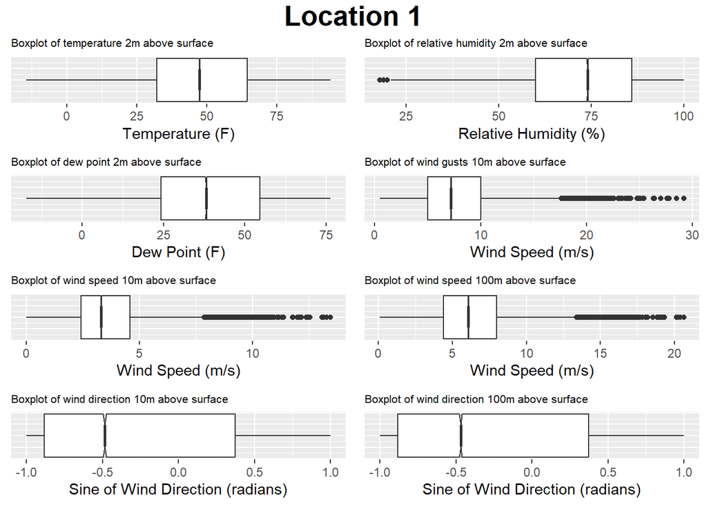

```r
# Generating a boxplot for the 'temperature' column using ggplot2
temperature.boxplot <- ggplot(location1, aes(y = temperature_2m)) +
  geom_boxplot(notch = TRUE) +
  labs(title = 'Boxplot of temperature 2m above surface', y = 'Temperature (F)') +
  theme(plot.title = element_text(size = 8), axis.text.y = element_blank(),
        axis.ticks.y = element_blank()) +
  coord_flip()

# Generating a boxplot for the 'relative humidity' column using ggplot2
humidity.boxplot <- ggplot(location1, aes(y = relativehumidity_2m)) +
  geom_boxplot(notch = TRUE) +
  labs(title = 'Boxplot of relative humidity 2m above surface', y = 'Relative Humidity (%)') +
  theme(plot.title = element_text(size = 8), axis.text.y = element_blank(),
        axis.ticks.y = element_blank()) +
  coord_flip()

# Generating a boxplot for the 'dewpoint' column using ggplot2
dewpoint.boxplot <- ggplot(location1, aes(y = dewpoint_2m)) +
  geom_boxplot(notch = TRUE) +
  labs(title = 'Boxplot of dew point 2m above surface', y = 'Dew Point (F)') +
  theme(plot.title = element_text(size = 8), axis.text.y = element_blank(),
        axis.ticks.y = element_blank()) +
  coord_flip()

# Generating a boxplot for the 'wind gusts (100m)' column using ggplot2
windgusts.boxplot <- ggplot(location1, aes(y = windgusts_10m)) +
  geom_boxplot(notch = TRUE) +
  labs(title = 'Boxplot of wind gusts 10m above surface', y = 'Wind Speed (m/s)') +
  theme(plot.title = element_text(size = 8), axis.text.y = element_blank(),
        axis.ticks.y = element_blank()) +
  coord_flip()

# Generating a boxplot for the 'wind speed (10m)' column using ggplot2
windspeed10m.boxplot <- ggplot(location1, aes(y = windspeed_10m)) +
  geom_boxplot(notch = TRUE) +
  labs(title = 'Boxplot of wind speed 10m above surface', y = 'Wind Speed (m/s)') +
  theme(plot.title = element_text(size = 8), axis.text.y = element_blank(),
        axis.ticks.y = element_blank()) +
  coord_flip()

# Generating a boxplot for the 'wind speed (100m)' column using ggplot2
windspeed100m.boxplot <- ggplot(location1, aes(y = windspeed_100m)) +
  geom_boxplot(notch = TRUE) +
  labs(title = 'Boxplot of wind speed 100m above surface', y = 'Wind Speed (m/s)') +
  theme(plot.title = element_text(size = 8), axis.text.y = element_blank(),
        axis.ticks.y = element_blank()) +
  coord_flip()

# Generating a boxplot for the 'wind direction (10m)' column using ggplot2
winddirection10m.boxplot <- ggplot(location1, aes(y = sin_wd_10_loc1)) +
  geom_boxplot(notch = TRUE) +
  labs(title = 'Boxplot of wind direction 10m above surface', y = 'Sine of Wind Direction (radians)') +
  theme(plot.title = element_text(size = 8), axis.text.y = element_blank(),
        axis.ticks.y = element_blank()) +
  coord_flip()

# Generating a boxplot for the 'wind direction (100m)' column using ggplot2
winddirection100m.boxplot <- ggplot(location1, aes(y = sin_wd_100_loc1)) +
  geom_boxplot(notch = TRUE) +
  labs(title = 'Boxplot of wind direction 100m above surface', y = 'Sine of Wind Direction (radians)') +
  theme(plot.title = element_text(size = 8), axis.text.y = element_blank(),
        axis.ticks.y = element_blank()) +
  coord_flip()

# Displaying all boxplots in the same panel
grid.arrange(temperature.boxplot, humidity.boxplot, dewpoint.boxplot, windgusts.boxplot, windspeed10m.boxplot, windspeed100m.boxplot, winddirection10m.boxplot, winddirection100m.boxplot,
               ncol = 2,
  top = textGrob("Location 1", gp = gpar(fontface = "bold", fontsize = 20)))
```

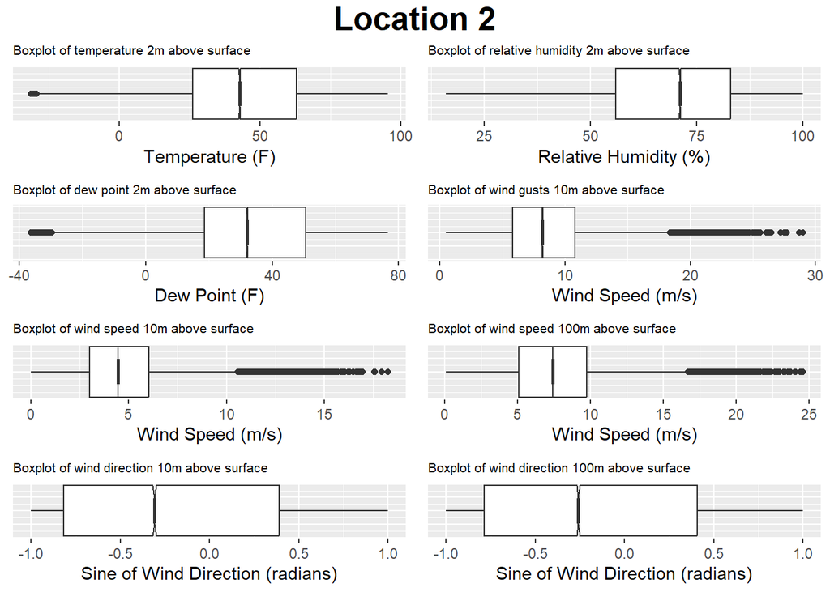

```r
# Generating a boxplot for the 'temperature' column using ggplot2
temperature.boxplot <- ggplot(location2, aes(y = temperature_2m)) +
  geom_boxplot(notch = TRUE) +
  labs(title = 'Boxplot of temperature 2m above surface', y = 'Temperature (F)') +
  theme(plot.title = element_text(size = 8), axis.text.y = element_blank(),
        axis.ticks.y = element_blank()) +
  coord_flip()

# Generating a boxplot for the 'relative humidity' column using ggplot2
humidity.boxplot <- ggplot(location2, aes(y = relativehumidity_2m)) +
  geom_boxplot(notch = TRUE) +
  labs(title = 'Boxplot of relative humidity 2m above surface', y = 'Relative Humidity (%)') +
  theme(plot.title = element_text(size = 8), axis.text.y = element_blank(),
        axis.ticks.y = element_blank()) +
  coord_flip()

# Generating a boxplot for the 'dewpoint' column using ggplot2
dewpoint.boxplot <- ggplot(location2, aes(y = dewpoint_2m)) +
  geom_boxplot(notch = TRUE) +
  labs(title = 'Boxplot of dew point 2m above surface', y = 'Dew Point (F)') +
  theme(plot.title = element_text(size = 8), axis.text.y = element_blank(),
        axis.ticks.y = element_blank()) +
  coord_flip()

# Generating a boxplot for the 'wind gusts (100m)' column using ggplot2
windgusts.boxplot <- ggplot(location2, aes(y = windgusts_10m)) +
  geom_boxplot(notch = TRUE) +
  labs(title = 'Boxplot of wind gusts 10m above surface', y = 'Wind Speed (m/s)') +
  theme(plot.title = element_text(size = 8), axis.text.y = element_blank(),
        axis.ticks.y = element_blank()) +
  coord_flip()

# Generating a boxplot for the 'wind speed (10m)' column using ggplot2
windspeed10m.boxplot <- ggplot(location2, aes(y = windspeed_10m)) +
  geom_boxplot(notch = TRUE) +
  labs(title = 'Boxplot of wind speed 10m above surface', y = 'Wind Speed (m/s)') +
  theme(plot.title = element_text(size = 8), axis.text.y = element_blank(),
        axis.ticks.y = element_blank()) +
  coord_flip()

# Generating a boxplot for the 'wind speed (100m)' column using ggplot2
windspeed100m.boxplot <- ggplot(location2, aes(y = windspeed_100m)) +
  geom_boxplot(notch = TRUE) +
  labs(title = 'Boxplot of wind speed 100m above surface', y = 'Wind Speed (m/s)') +
  theme(plot.title = element_text(size = 8), axis.text.y = element_blank(),
        axis.ticks.y = element_blank()) +
  coord_flip()

# Generating a boxplot for the 'wind direction (10m)' column using ggplot2
winddirection10m.boxplot <- ggplot(location2, aes(y = sin_wd_10_loc2)) +
  geom_boxplot(notch = TRUE) +
  labs(title = 'Boxplot of wind direction 10m above surface', y = 'Sine of Wind Direction (radians)') +
  theme(plot.title = element_text(size = 8), axis.text.y = element_blank(),
        axis.ticks.y = element_blank()) +
  coord_flip()

# Generating a boxplot for the 'wind direction (100m)' column using ggplot2
winddirection100m.boxplot <- ggplot(location2, aes(y = sin_wd_100_loc2)) +
  geom_boxplot(notch = TRUE) +
  labs(title = 'Boxplot of wind direction 100m above surface', y = 'Sine of Wind Direction (radians)') +
  theme(plot.title = element_text(size = 8), axis.text.y = element_blank(),
        axis.ticks.y = element_blank()) +
  coord_flip()

# Displaying all boxplots in the same panel
grid.arrange(temperature.boxplot, humidity.boxplot, dewpoint.boxplot, windgusts.boxplot, windspeed10m.boxplot, windspeed100m.boxplot, winddirection10m.boxplot, winddirection100m.boxplot,
               ncol = 2,
  top = textGrob("Location 2", gp = gpar(fontface = "bold", fontsize = 20)))
```

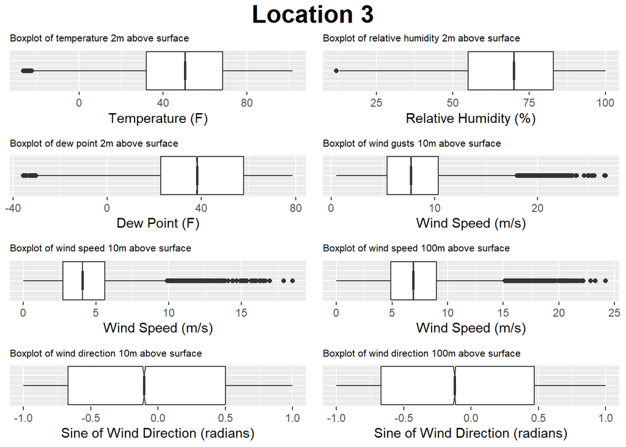

```r
# Generating a boxplot for the 'temperature' column using ggplot2
temperature.boxplot <- ggplot(location3, aes(y = temperature_2m)) +
  geom_boxplot(notch = TRUE) +
  labs(title = 'Boxplot of temperature 2m above surface', y = 'Temperature (F)') +
  theme(plot.title = element_text(size = 8), axis.text.y = element_blank(),
        axis.ticks.y = element_blank()) +
  coord_flip()

# Generating a boxplot for the 'relative humidity' column using ggplot2
humidity.boxplot <- ggplot(location3, aes(y = relativehumidity_2m)) +
  geom_boxplot(notch = TRUE) +
  labs(title = 'Boxplot of relative humidity 2m above surface', y = 'Relative Humidity (%)') +
  theme(plot.title = element_text(size = 8), axis.text.y = element_blank(),
        axis.ticks.y = element_blank()) +
  coord_flip()

# Generating a boxplot for the 'dewpoint' column using ggplot2
dewpoint.boxplot <- ggplot(location3, aes(y = dewpoint_2m)) +
  geom_boxplot(notch = TRUE) +
  labs(title = 'Boxplot of dew point 2m above surface', y = 'Dew Point (F)') +
  theme(plot.title = element_text(size = 8), axis.text.y = element_blank(),
        axis.ticks.y = element_blank()) +
  coord_flip()

# Generating a boxplot for the 'wind gusts (100m)' column using ggplot2
windgusts.boxplot <- ggplot(location3, aes(y = windgusts_10m)) +
  geom_boxplot(notch = TRUE) +
  labs(title = 'Boxplot of wind gusts 10m above surface', y = 'Wind Speed (m/s)') +
  theme(plot.title = element_text(size = 8), axis.text.y = element_blank(),
        axis.ticks.y = element_blank()) +
  coord_flip()

# Generating a boxplot for the 'wind speed (10m)' column using ggplot2
windspeed10m.boxplot <- ggplot(location3, aes(y = windspeed_10m)) +
  geom_boxplot(notch = TRUE) +
  labs(title = 'Boxplot of wind speed 10m above surface', y = 'Wind Speed (m/s)') +
  theme(plot.title = element_text(size = 8), axis.text.y = element_blank(),
        axis.ticks.y = element_blank()) +
  coord_flip()

# Generating a boxplot for the 'wind speed (100m)' column using ggplot2
windspeed100m.boxplot <- ggplot(location3, aes(y = windspeed_100m)) +
  geom_boxplot(notch = TRUE) +
  labs(title = 'Boxplot of wind speed 100m above surface', y = 'Wind Speed (m/s)') +
  theme(plot.title = element_text(size = 8), axis.text.y = element_blank(),
        axis.ticks.y = element_blank()) +
  coord_flip()

# Generating a boxplot for the 'wind direction (10m)' column using ggplot2
winddirection10m.boxplot <- ggplot(location3, aes(y = sin_wd_10_loc3)) +
  geom_boxplot(notch = TRUE) +
  labs(title = 'Boxplot of wind direction 10m above surface', y = 'Sine of Wind Direction (radians)') +
  theme(plot.title = element_text(size = 8), axis.text.y = element_blank(),
        axis.ticks.y = element_blank()) +
  coord_flip()

# Generating a boxplot for the 'wind direction (100m)' column using ggplot2
winddirection100m.boxplot <- ggplot(location3, aes(y = sin_wd_100_loc3)) +
  geom_boxplot(notch = TRUE) +
  labs(title = 'Boxplot of wind direction 100m above surface', y = 'Sine of Wind Direction (radians)') +
  theme(plot.title = element_text(size = 8), axis.text.y = element_blank(),
        axis.ticks.y = element_blank()) +
  coord_flip()

# Displaying all boxplots in the same panel
grid.arrange(temperature.boxplot, humidity.boxplot, dewpoint.boxplot, windgusts.boxplot, windspeed10m.boxplot, windspeed100m.boxplot, winddirection10m.boxplot, winddirection100m.boxplot,
               ncol = 2,
  top = textGrob("Location 3", gp = gpar(fontface = "bold", fontsize = 20)))
```

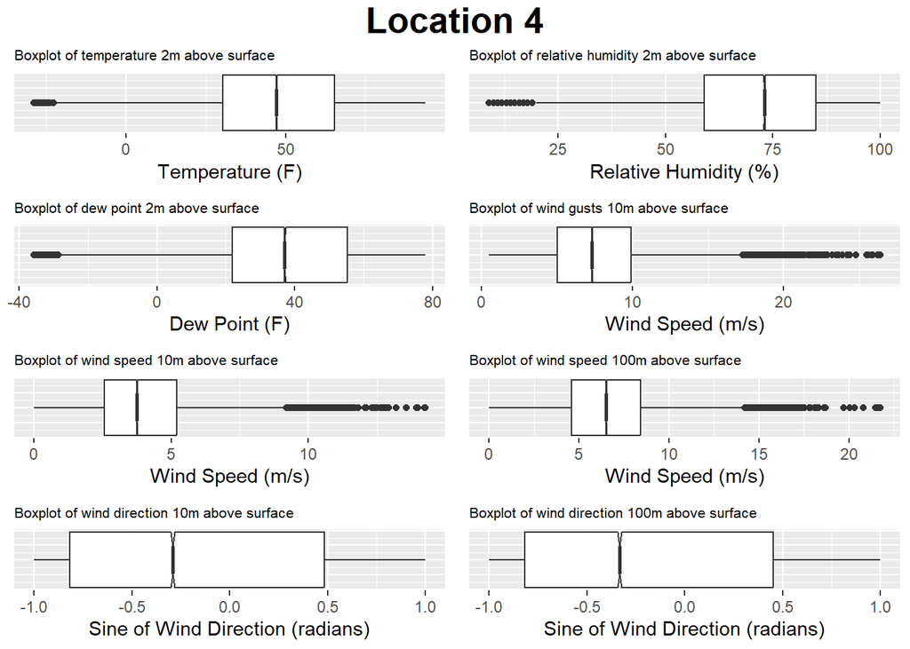

```r
# Generating a boxplot for the 'temperature' column using ggplot2
temperature.boxplot <- ggplot(location4, aes(y = temperature_2m)) +
  geom_boxplot(notch = TRUE) +
  labs(title = 'Boxplot of temperature 2m above surface', y = 'Temperature (F)') +
  theme(plot.title = element_text(size = 8), axis.text.y = element_blank(),
        axis.ticks.y = element_blank()) +
  coord_flip()

# Generating a boxplot for the 'relative humidity' column using ggplot2
humidity.boxplot <- ggplot(location4, aes(y = relativehumidity_2m)) +
  geom_boxplot(notch = TRUE) +
  labs(title = 'Boxplot of relative humidity 2m above surface', y = 'Relative Humidity (%)') +
  theme(plot.title = element_text(size = 8), axis.text.y = element_blank(),
        axis.ticks.y = element_blank()) +
  coord_flip()

# Generating a boxplot for the 'dewpoint' column using ggplot2
dewpoint.boxplot <- ggplot(location4, aes(y = dewpoint_2m)) +
  geom_boxplot(notch = TRUE) +
  labs(title = 'Boxplot of dew point 2m above surface', y = 'Dew Point (F)') +
  theme(plot.title = element_text(size = 8), axis.text.y = element_blank(),
        axis.ticks.y = element_blank()) +
  coord_flip()

# Generating a boxplot for the 'wind gusts (100m)' column using ggplot2
windgusts.boxplot <- ggplot(location4, aes(y = windgusts_10m)) +
  geom_boxplot(notch = TRUE) +
  labs(title = 'Boxplot of wind gusts 10m above surface', y = 'Wind Speed (m/s)') +
  theme(plot.title = element_text(size = 8), axis.text.y = element_blank(),
        axis.ticks.y = element_blank()) +
  coord_flip()

# Generating a boxplot for the 'wind speed (10m)' column using ggplot2
windspeed10m.boxplot <- ggplot(location4, aes(y = windspeed_10m)) +
  geom_boxplot(notch = TRUE) +
  labs(title = 'Boxplot of wind speed 10m above surface', y = 'Wind Speed (m/s)') +
  theme(plot.title = element_text(size = 8), axis.text.y = element_blank(),
        axis.ticks.y = element_blank()) +
  coord_flip()

# Generating a boxplot for the 'wind speed (100m)' column using ggplot2
windspeed100m.boxplot <- ggplot(location4, aes(y = windspeed_100m)) +
  geom_boxplot(notch = TRUE) +
  labs(title = 'Boxplot of wind speed 100m above surface', y = 'Wind Speed (m/s)') +
  theme(plot.title = element_text(size = 8), axis.text.y = element_blank(),
        axis.ticks.y = element_blank()) +
  coord_flip()

# Generating a boxplot for the 'wind direction (10m)' column using ggplot2
winddirection10m.boxplot <- ggplot(location4, aes(y = sin_wd_10_loc4)) +
  geom_boxplot(notch = TRUE) +
  labs(title = 'Boxplot of wind direction 10m above surface', y = 'Sine of Wind Direction (radians)') +
  theme(plot.title = element_text(size = 8), axis.text.y = element_blank(),
        axis.ticks.y = element_blank()) +
  coord_flip()

# Generating a boxplot for the 'wind direction (100m)' column using ggplot2
winddirection100m.boxplot <- ggplot(location4, aes(y = sin_wd_100_loc4)) +
  geom_boxplot(notch = TRUE) +
  labs(title = 'Boxplot of wind direction 100m above surface', y = 'Sine of Wind Direction (radians)') +
  theme(plot.title = element_text(size = 8), axis.text.y = element_blank(),
        axis.ticks.y = element_blank()) +
  coord_flip()

# Displaying all boxplots in the same panel
grid.arrange(temperature.boxplot, humidity.boxplot, dewpoint.boxplot, windgusts.boxplot, windspeed10m.boxplot, windspeed100m.boxplot, winddirection10m.boxplot, winddirection100m.boxplot,
               ncol = 2,
  top = textGrob("Location 4", gp = gpar(fontface = "bold", fontsize = 20)))
```

#Investigating Variables

In order to make the future machine learning model more accurate, it is worth removing noisy variables from the dataset, i.e., variables that do not have a significant effect on the power generated. It would also be good to remove explanatory variables that are highly correlated to remove any issues associated with multi-collinearity.

To identify both scenarios, I will use a use a correlation plot:

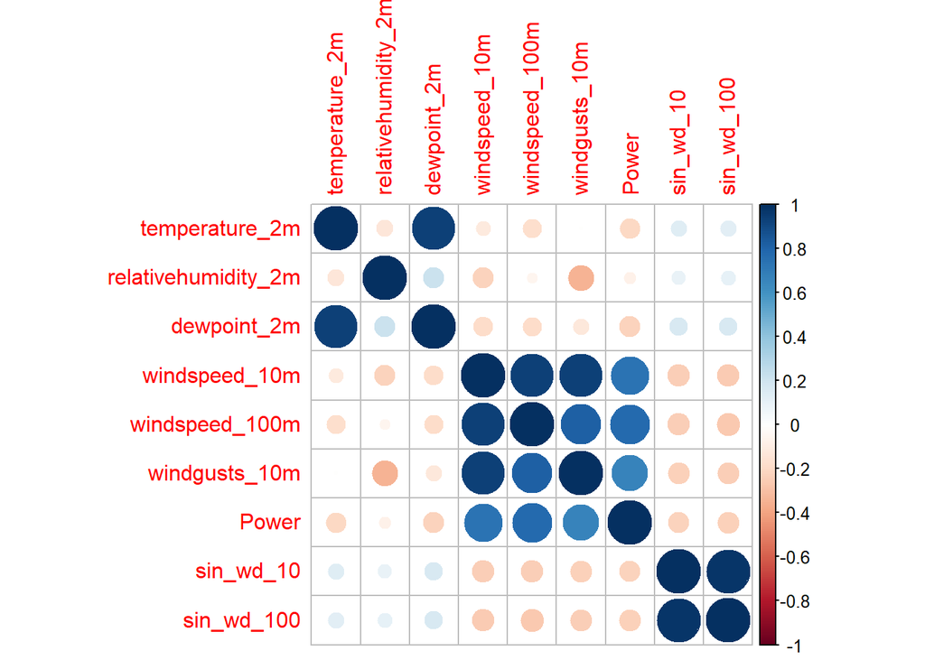

```r
#Removing Date, and wind direction columns in degrees (keeping radians instead)
location1_numeric <- select(location1, -c("Time", "winddirection_10m", "winddirection_100m"))
correlation_1 <- cor(location1_numeric)
corr_plot_1 <- corrplot(correlation_1, method = 'circle')
```

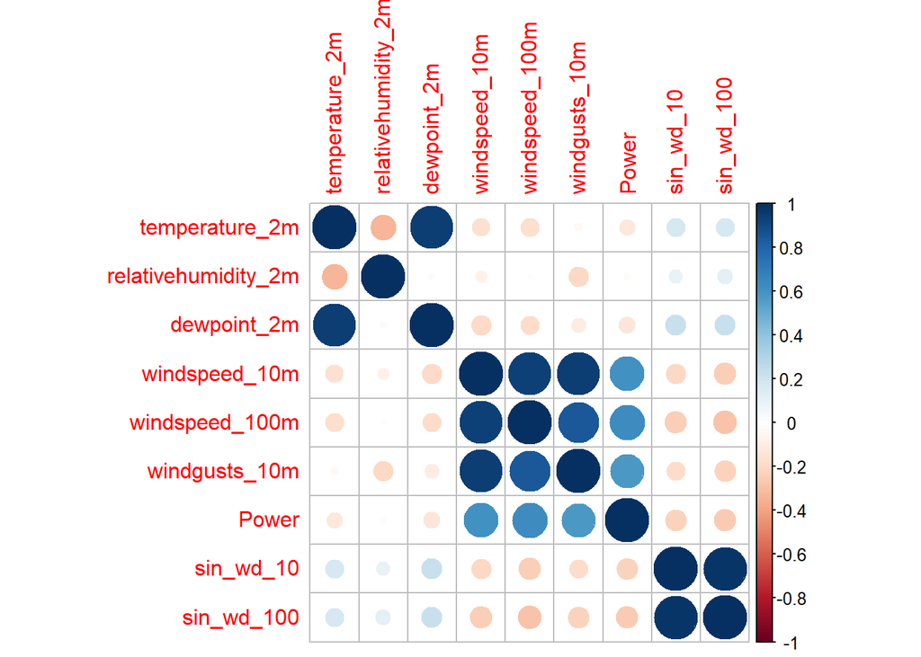

```r
location2_numeric <- select(location2, -c("Time", "winddirection_10m", "winddirection_100m"))
correlation_2 <- cor(location2_numeric)
corr_plot_2 <- corrplot(correlation_2, method = 'circle')
```

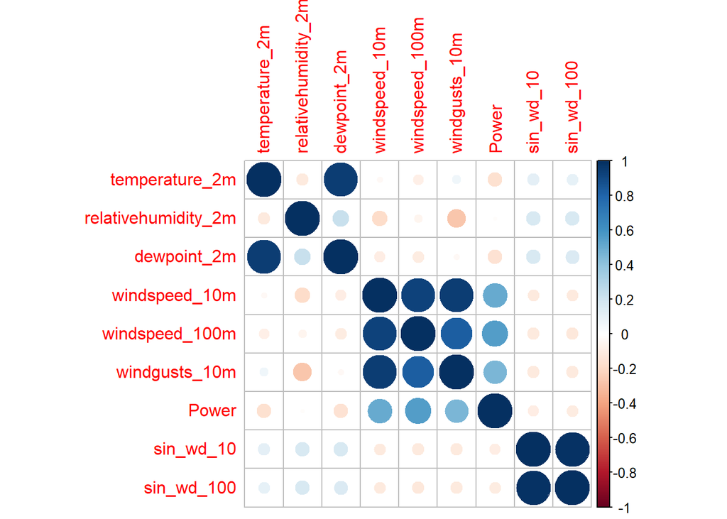

```r
location3_numeric <- select(location3, -c("Time", "winddirection_10m", "winddirection_100m"))
correlation_3 <- cor(location3_numeric)
corr_plot_3 <- corrplot(correlation_3, method = 'circle')
```

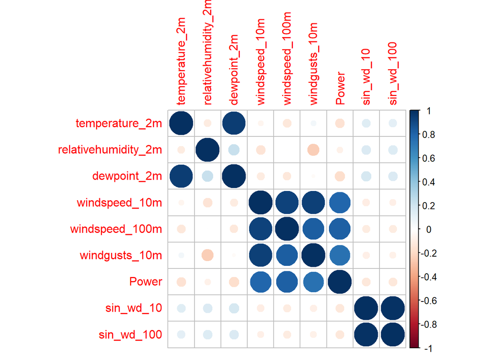

```r
location4_numeric <- select(location4, -c("Time", "winddirection_10m", "winddirection_100m"))
correlation_4 <- cor(location4_numeric)
corr_plot_4 <- corrplot(correlation_4, method = 'circle')
```

```r
corr_plot_1
```

```
## $corr
##                     temperature_2m relativehumidity_2m dewpoint_2m
## temperature_2m         1.000000000         -0.13799282   0.9348133
## relativehumidity_2m   -0.137992816          1.00000000   0.2176570
## dewpoint_2m            0.934813335          0.21765703   1.0000000
## windspeed_10m         -0.112035658         -0.22181049  -0.1858997
## windspeed_100m        -0.172389723         -0.05275183  -0.1839376
## windgusts_10m         -0.008929033         -0.34235666  -0.1273754
## Power                 -0.207100754         -0.07035996  -0.2237392
## sin_wd_10              0.133654647          0.09563770   0.1646627
## sin_wd_100             0.125981110          0.10789816   0.1608025
##                     windspeed_10m windspeed_100m windgusts_10m       Power
## temperature_2m         -0.1120357    -0.17238972  -0.008929033 -0.20710075
## relativehumidity_2m    -0.2218105    -0.05275183  -0.342356659 -0.07035996
## dewpoint_2m            -0.1858997    -0.18393762  -0.127375417 -0.22373920
## windspeed_10m           1.0000000     0.93298146   0.936676530  0.73280075
## windspeed_100m          0.9329815     1.00000000   0.819064871  0.77870432
## windgusts_10m           0.9366765     0.81906487   1.000000000  0.66267656
## Power                   0.7328008     0.77870432   0.662676564  1.00000000
## sin_wd_10              -0.2482625    -0.24817093  -0.233527512 -0.22608427
## sin_wd_100             -0.2559224    -0.26105121  -0.240777814 -0.23919123
##                      sin_wd_10 sin_wd_100
## temperature_2m       0.1336546  0.1259811
## relativehumidity_2m  0.0956377  0.1078982
## dewpoint_2m          0.1646627  0.1608025
## windspeed_10m       -0.2482625 -0.2559224
## windspeed_100m      -0.2481709 -0.2610512
## windgusts_10m       -0.2335275 -0.2407778
## Power               -0.2260843 -0.2391912
## sin_wd_10            1.0000000  0.9791444
## sin_wd_100           0.9791444  1.0000000
##
## $corrPos
##                  xName               yName x y         corr
## 1       temperature_2m      temperature_2m 1 9  1.000000000
## 2       temperature_2m relativehumidity_2m 1 8 -0.137992816
## 3       temperature_2m         dewpoint_2m 1 7  0.934813335
## 4       temperature_2m       windspeed_10m 1 6 -0.112035658
## 5       temperature_2m      windspeed_100m 1 5 -0.172389723
## 6       temperature_2m       windgusts_10m 1 4 -0.008929033
```

[output cut: 64 more lines]

```
## 71           sin_wd_10           sin_wd_10 8 2  1.000000000
## 72           sin_wd_10          sin_wd_100 8 1  0.979144437
## 73          sin_wd_100      temperature_2m 9 9  0.125981110
## 74          sin_wd_100 relativehumidity_2m 9 8  0.107898155
## 75          sin_wd_100         dewpoint_2m 9 7  0.160802546
## 76          sin_wd_100       windspeed_10m 9 6 -0.255922438
## 77          sin_wd_100      windspeed_100m 9 5 -0.261051206
## 78          sin_wd_100       windgusts_10m 9 4 -0.240777814
## 79          sin_wd_100               Power 9 3 -0.239191232
## 80          sin_wd_100           sin_wd_10 9 2  0.979144437
## 81          sin_wd_100          sin_wd_100 9 1  1.000000000
##
## $arg
## $arg$type
## [1] "full"
```

```r
corr_plot_2
```

```
## $corr
##                     temperature_2m relativehumidity_2m dewpoint_2m
## temperature_2m           1.0000000         -0.33718906   0.9479079
## relativehumidity_2m     -0.3371891          1.00000000  -0.0262179
## dewpoint_2m              0.9479079         -0.02621790   1.0000000
## windspeed_10m           -0.1651856         -0.07326962  -0.1988913
## windspeed_100m          -0.1799186          0.01171110  -0.1823417
## windgusts_10m           -0.0358283         -0.20697750  -0.1061056
## Power                   -0.1292908         -0.02599645  -0.1399299
## sin_wd_10                0.1797000          0.09677664   0.2205195
## sin_wd_100               0.1725801          0.11883597   0.2205127
##                     windspeed_10m windspeed_100m windgusts_10m       Power
## temperature_2m        -0.16518558     -0.1799186    -0.0358283 -0.12929081
## relativehumidity_2m   -0.07326962      0.0117111    -0.2069775 -0.02599645
## dewpoint_2m           -0.19889132     -0.1823417    -0.1061056 -0.13992991
## windspeed_10m          1.00000000      0.9360675     0.9423962  0.60588934
## windspeed_100m         0.93606754      1.0000000     0.8482897  0.62872183
## windgusts_10m          0.94239615      0.8482897     1.0000000  0.57562239
## Power                  0.60588934      0.6287218     0.5756224  1.00000000
## sin_wd_10             -0.20774556     -0.2447469    -0.1808128 -0.22854369
## sin_wd_100            -0.24700006     -0.2822235    -0.2298395 -0.25001268
##                       sin_wd_10 sin_wd_100
## temperature_2m       0.17969996  0.1725801
## relativehumidity_2m  0.09677664  0.1188360
## dewpoint_2m          0.22051952  0.2205127
## windspeed_10m       -0.20774556 -0.2470001
## windspeed_100m      -0.24474692 -0.2822235
## windgusts_10m       -0.18081285 -0.2298395
## Power               -0.22854369 -0.2500127
## sin_wd_10            1.00000000  0.9789138
## sin_wd_100           0.97891376  1.0000000
##
## $corrPos
##                  xName               yName x y        corr
## 1       temperature_2m      temperature_2m 1 9  1.00000000
## 2       temperature_2m relativehumidity_2m 1 8 -0.33718906
## 3       temperature_2m         dewpoint_2m 1 7  0.94790791
## 4       temperature_2m       windspeed_10m 1 6 -0.16518558
## 5       temperature_2m      windspeed_100m 1 5 -0.17991856
## 6       temperature_2m       windgusts_10m 1 4 -0.03582830
```

[output cut: 64 more lines]

```
## 71           sin_wd_10           sin_wd_10 8 2  1.00000000
## 72           sin_wd_10          sin_wd_100 8 1  0.97891376
## 73          sin_wd_100      temperature_2m 9 9  0.17258007
## 74          sin_wd_100 relativehumidity_2m 9 8  0.11883597
## 75          sin_wd_100         dewpoint_2m 9 7  0.22051271
## 76          sin_wd_100       windspeed_10m 9 6 -0.24700006
## 77          sin_wd_100      windspeed_100m 9 5 -0.28222353
## 78          sin_wd_100       windgusts_10m 9 4 -0.22983948
## 79          sin_wd_100               Power 9 3 -0.25001268
## 80          sin_wd_100           sin_wd_10 9 2  0.97891376
## 81          sin_wd_100          sin_wd_100 9 1  1.00000000
##
## $arg
## $arg$type
## [1] "full"
```

```r
corr_plot_3
```

```
## $corr
##                     temperature_2m relativehumidity_2m dewpoint_2m
## temperature_2m          1.00000000         -0.11631406  0.94044764
## relativehumidity_2m    -0.11631406          1.00000000  0.22277823
## dewpoint_2m             0.94044764          0.22277823  1.00000000
## windspeed_10m          -0.03181764         -0.18466713 -0.09348243
## windspeed_100m         -0.08904348         -0.05463214 -0.10302756
## windgusts_10m           0.06408000         -0.27620986 -0.03113602
## Power                  -0.16339018         -0.01308227 -0.15918059
## sin_wd_10               0.11492165          0.16179237  0.16779109
## sin_wd_100              0.10509819          0.16144617  0.15784557
##                     windspeed_10m windspeed_100m windgusts_10m       Power
## temperature_2m        -0.03181764    -0.08904348    0.06408000 -0.16339018
## relativehumidity_2m   -0.18466713    -0.05463214   -0.27620986 -0.01308227
## dewpoint_2m           -0.09348243    -0.10302756   -0.03113602 -0.15918059
## windspeed_10m          1.00000000     0.92468979    0.94126546  0.50000977
## windspeed_100m         0.92468979     1.00000000    0.82329502  0.55733581
## windgusts_10m          0.94126546     0.82329502    1.00000000  0.45392324
## Power                  0.50000977     0.55733581    0.45392324  1.00000000
## sin_wd_10             -0.11187342    -0.11696457   -0.11559538 -0.09721323
## sin_wd_100            -0.11070181    -0.12290601   -0.11380600 -0.10488310
##                       sin_wd_10 sin_wd_100
## temperature_2m       0.11492165  0.1050982
## relativehumidity_2m  0.16179237  0.1614462
## dewpoint_2m          0.16779109  0.1578456
## windspeed_10m       -0.11187342 -0.1107018
## windspeed_100m      -0.11696457 -0.1229060
## windgusts_10m       -0.11559538 -0.1138060
## Power               -0.09721323 -0.1048831
## sin_wd_10            1.00000000  0.9824099
## sin_wd_100           0.98240995  1.0000000
##
## $corrPos
##                  xName               yName x y        corr
## 1       temperature_2m      temperature_2m 1 9  1.00000000
## 2       temperature_2m relativehumidity_2m 1 8 -0.11631406
## 3       temperature_2m         dewpoint_2m 1 7  0.94044764
## 4       temperature_2m       windspeed_10m 1 6 -0.03181764
## 5       temperature_2m      windspeed_100m 1 5 -0.08904348
## 6       temperature_2m       windgusts_10m 1 4  0.06408000
```

[output cut: 64 more lines]

```
## 71           sin_wd_10           sin_wd_10 8 2  1.00000000
## 72           sin_wd_10          sin_wd_100 8 1  0.98240995
## 73          sin_wd_100      temperature_2m 9 9  0.10509819
## 74          sin_wd_100 relativehumidity_2m 9 8  0.16144617
## 75          sin_wd_100         dewpoint_2m 9 7  0.15784557
## 76          sin_wd_100       windspeed_10m 9 6 -0.11070181
## 77          sin_wd_100      windspeed_100m 9 5 -0.12290601
## 78          sin_wd_100       windgusts_10m 9 4 -0.11380600
## 79          sin_wd_100               Power 9 3 -0.10488310
## 80          sin_wd_100           sin_wd_10 9 2  0.98240995
## 81          sin_wd_100          sin_wd_100 9 1  1.00000000
##
## $arg
## $arg$type
## [1] "full"
```

```r
corr_plot_4
```

```
## $corr
##                     temperature_2m relativehumidity_2m dewpoint_2m
## temperature_2m          1.00000000        -0.100902178  0.94563720
## relativehumidity_2m    -0.10090218         1.000000000  0.22335029
## dewpoint_2m             0.94563720         0.223350287  1.00000000
## windspeed_10m          -0.05727320        -0.146456192 -0.10244891
## windspeed_100m         -0.12478641        -0.001301028 -0.12001438
## windgusts_10m           0.05541472        -0.244081997 -0.02450753
## Power                  -0.15396683        -0.074057608 -0.17208960
## sin_wd_10               0.13136388         0.150356054  0.17620621
## sin_wd_100              0.11378380         0.146364234  0.15754837
##                     windspeed_10m windspeed_100m windgusts_10m       Power
## temperature_2m        -0.05727320   -0.124786407    0.05541472 -0.15396683
## relativehumidity_2m   -0.14645619   -0.001301028   -0.24408200 -0.07405761
## dewpoint_2m           -0.10244891   -0.120014383   -0.02450753 -0.17208960
## windspeed_10m          1.00000000    0.925958809    0.93823541  0.79647026
## windspeed_100m         0.92595881    1.000000000    0.82101329  0.81866256
## windgusts_10m          0.93823541    0.821013288    1.00000000  0.74193694
## Power                  0.79647026    0.818662561    0.74193694  1.00000000
## sin_wd_10             -0.09309411   -0.108457270   -0.08834754 -0.12578133
## sin_wd_100            -0.08328979   -0.103492239   -0.07835635 -0.12423887
##                       sin_wd_10  sin_wd_100
## temperature_2m       0.13136388  0.11378380
## relativehumidity_2m  0.15035605  0.14636423
## dewpoint_2m          0.17620621  0.15754837
## windspeed_10m       -0.09309411 -0.08328979
## windspeed_100m      -0.10845727 -0.10349224
## windgusts_10m       -0.08834754 -0.07835635
## Power               -0.12578133 -0.12423887
## sin_wd_10            1.00000000  0.98392036
## sin_wd_100           0.98392036  1.00000000
##
## $corrPos
##                  xName               yName x y         corr
## 1       temperature_2m      temperature_2m 1 9  1.000000000
## 2       temperature_2m relativehumidity_2m 1 8 -0.100902178
## 3       temperature_2m         dewpoint_2m 1 7  0.945637202
## 4       temperature_2m       windspeed_10m 1 6 -0.057273197
## 5       temperature_2m      windspeed_100m 1 5 -0.124786407
## 6       temperature_2m       windgusts_10m 1 4  0.055414720
```

[output cut: 64 more lines]

```
## 71           sin_wd_10           sin_wd_10 8 2  1.000000000
## 72           sin_wd_10          sin_wd_100 8 1  0.983920359
## 73          sin_wd_100      temperature_2m 9 9  0.113783802
## 74          sin_wd_100 relativehumidity_2m 9 8  0.146364234
## 75          sin_wd_100         dewpoint_2m 9 7  0.157548370
## 76          sin_wd_100       windspeed_10m 9 6 -0.083289794
## 77          sin_wd_100      windspeed_100m 9 5 -0.103492239
## 78          sin_wd_100       windgusts_10m 9 4 -0.078356352
## 79          sin_wd_100               Power 9 3 -0.124238875
## 80          sin_wd_100           sin_wd_10 9 2  0.983920359
## 81          sin_wd_100          sin_wd_100 9 1  1.000000000
##
## $arg
## $arg$type
## [1] "full"
```

The plot also shows us which explanatory variables are correlated:

- temperature and dewpoint
- wind speed at 10m and wind speed at 100m
- wind direction at 10m and wind direction at 100m
- wind gusts and wind speed at 10m
- wind gusts and wind speed at 100m

To avoid issues related to multi-collinearity it would be only select one variable from each pair (preferably the one that has a stronger correlation with Power).

As correlations appear to be similar across all locations, I will only run the tests for Location 1.

Investigating temperature and dew point:

```r
cor.test(location1$temperature_2m, location1$dewpoint_2m)
```

```
##
##  Pearson's product-moment correlation
##
## data:  location1$temperature_2m and location1$dewpoint_2m
## t = 550.88, df = 43798, p-value < 2.2e-16
## alternative hypothesis: true correlation is not equal to 0
## 95 percent confidence interval:
##  0.9336217 0.9359843
## sample estimates:
##       cor
## 0.9348133
```

The correlation is significant

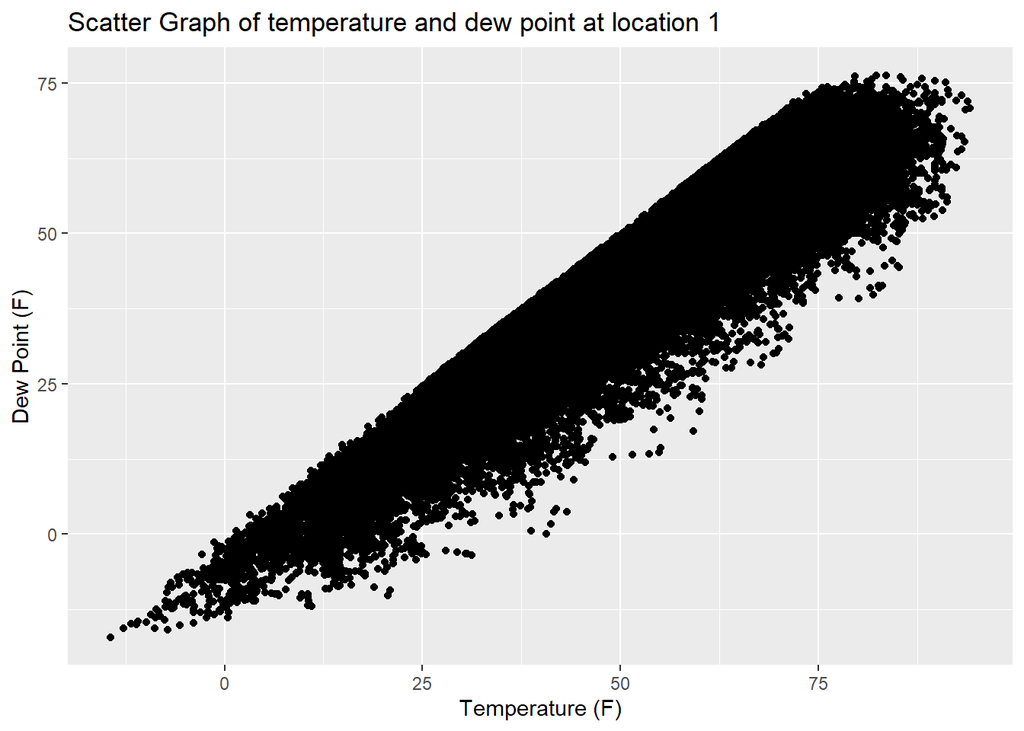

```r
ggplot(location1, aes(x = temperature_2m, y = dewpoint_2m)) +
  geom_point() +
  labs(title = 'Scatter Graph of temperature and dew point at location 1', x = 'Temperature (F)', y = 'Dew Point (F)')
```

Investigating which has a greater correlation with Power using a linear model:

```r
temperature_power_lm <- lm(location1$Power~location1$temperature_2m)
dewpoint_power_lm <- lm(location1$Power~location1$dewpoint_2m)

summary(temperature_power_lm)
```

```
##
## Call:
## lm(formula = location1$Power ~ location1$temperature_2m)
##
## Residuals:
##      Min       1Q   Median       3Q      Max
## -0.52895 -0.24604 -0.05481  0.23675  0.67818
##
## Coefficients:
##                            Estimate Std. Error t value Pr(>|t|)
## (Intercept)               5.523e-01  3.580e-03   154.3   <2e-16 ***
## location1$temperature_2m -3.069e-03  6.928e-05   -44.3   <2e-16 ***
## ---
## Signif. codes:  0 '***' 0.001 '**' 0.01 '*' 0.05 '.' 0.1 ' ' 1
##
## Residual standard error: 0.2821 on 43798 degrees of freedom
## Multiple R-squared:  0.04289,    Adjusted R-squared:  0.04287
## F-statistic:  1963 on 1 and 43798 DF,  p-value: < 2.2e-16
```

```r
summary(dewpoint_power_lm)
```

```
##
## Call:
## lm(formula = location1$Power ~ location1$dewpoint_2m)
##
## Residuals:
##      Min       1Q   Median       3Q      Max
## -0.53572 -0.24418 -0.05384  0.23497  0.68750
##
## Coefficients:
##                         Estimate Std. Error t value Pr(>|t|)
## (Intercept)            5.379e-01  3.068e-03  175.32   <2e-16 ***
## location1$dewpoint_2m -3.436e-03  7.153e-05  -48.04   <2e-16 ***
## ---
## Signif. codes:  0 '***' 0.001 '**' 0.01 '*' 0.05 '.' 0.1 ' ' 1
##
## Residual standard error: 0.281 on 43798 degrees of freedom
## Multiple R-squared:  0.05006,    Adjusted R-squared:  0.05004
## F-statistic:  2308 on 1 and 43798 DF,  p-value: < 2.2e-16
```

The differences are extremely subtle, so I’ve chosen to keep temperature and exclude dew point.

Investigating wind speed 10m and wind speed 100m:

```r
cor.test(location1$windspeed_10m, location1$windspeed_100m)
```

```
##
##  Pearson's product-moment correlation
##
## data:  location1$windspeed_10m and location1$windspeed_100m
## t = 542.49, df = 43798, p-value < 2.2e-16
## alternative hypothesis: true correlation is not equal to 0
## 95 percent confidence interval:
##  0.9317576 0.9341842
## sample estimates:
##       cor
## 0.9329815
```

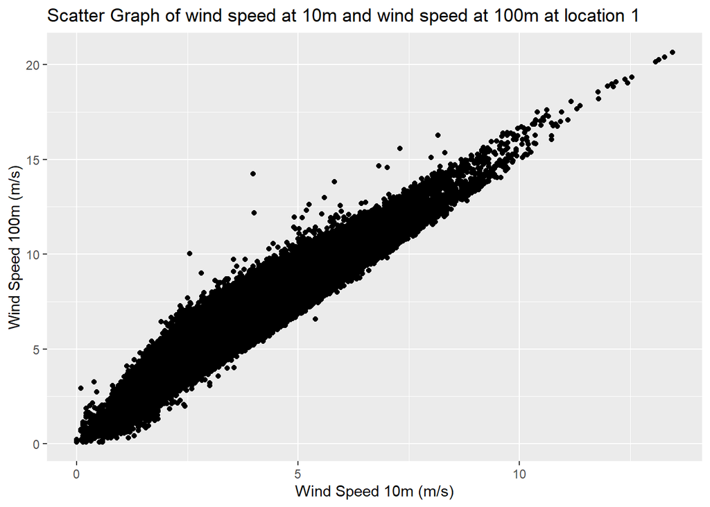

```r
ggplot(location1, aes(x = windspeed_10m, y = windspeed_100m)) +
  geom_point() +
  labs(title = 'Scatter Graph of wind speed at 10m and wind speed at 100m at location 1', x = 'Wind Speed 10m (m/s)', y = 'Wind Speed 100m (m/s)')
```

```r
windspeed10_power_lm <- lm(location1$Power~location1$windspeed_10m)
windspeed100_power_lm <- lm(location1$Power~location1$windspeed_100m)

summary(windspeed10_power_lm)
```

```
##
## Call:
## lm(formula = location1$Power ~ location1$windspeed_10m)
##
## Residuals:
##      Min       1Q   Median       3Q      Max
## -1.33268 -0.13628 -0.01578  0.13320  0.75410
##
## Coefficients:
##                           Estimate Std. Error t value Pr(>|t|)
## (Intercept)             -0.0546522  0.0022461  -24.33   <2e-16 ***
## location1$windspeed_10m  0.1281032  0.0005684  225.38   <2e-16 ***
## ---
## Signif. codes:  0 '***' 0.001 '**' 0.01 '*' 0.05 '.' 0.1 ' ' 1
##
## Residual standard error: 0.1962 on 43798 degrees of freedom
## Multiple R-squared:  0.537,  Adjusted R-squared:  0.537
## F-statistic: 5.08e+04 on 1 and 43798 DF,  p-value: < 2.2e-16
```

```r
summary(windspeed100_power_lm)
```

```
##
## Call:
## lm(formula = location1$Power ~ location1$windspeed_100m)
##
## Residuals:
##     Min      1Q  Median      3Q     Max
## -1.3024 -0.1226 -0.0082  0.1232  0.8501
##
## Coefficients:
##                            Estimate Std. Error t value Pr(>|t|)
## (Intercept)              -0.1200727  0.0021998  -54.58   <2e-16 ***
## location1$windspeed_100m  0.0836126  0.0003219  259.75   <2e-16 ***
## ---
## Signif. codes:  0 '***' 0.001 '**' 0.01 '*' 0.05 '.' 0.1 ' ' 1
##
## Residual standard error: 0.1809 on 43798 degrees of freedom
## Multiple R-squared:  0.6064, Adjusted R-squared:  0.6064
## F-statistic: 6.747e+04 on 1 and 43798 DF,  p-value: < 2.2e-16
```

Again, the differences are negligible, so I have decided to keep wind speed at 100m instead of wind speed at 10m as it can be assumed that this height is closer to the level of the spinning section of the turbine.

Investigating wind gusts and wind speed 100m:

```r
cor.test(location1$windspeed_100m, location1$windgusts_10m)
```

```
##
##  Pearson's product-moment correlation
##
## data:  location1$windspeed_100m and location1$windgusts_10m
## t = 298.79, df = 43798, p-value < 2.2e-16
## alternative hypothesis: true correlation is not equal to 0
## 95 percent confidence interval:
##  0.8159587 0.8221238
## sample estimates:
##       cor
## 0.8190649
```

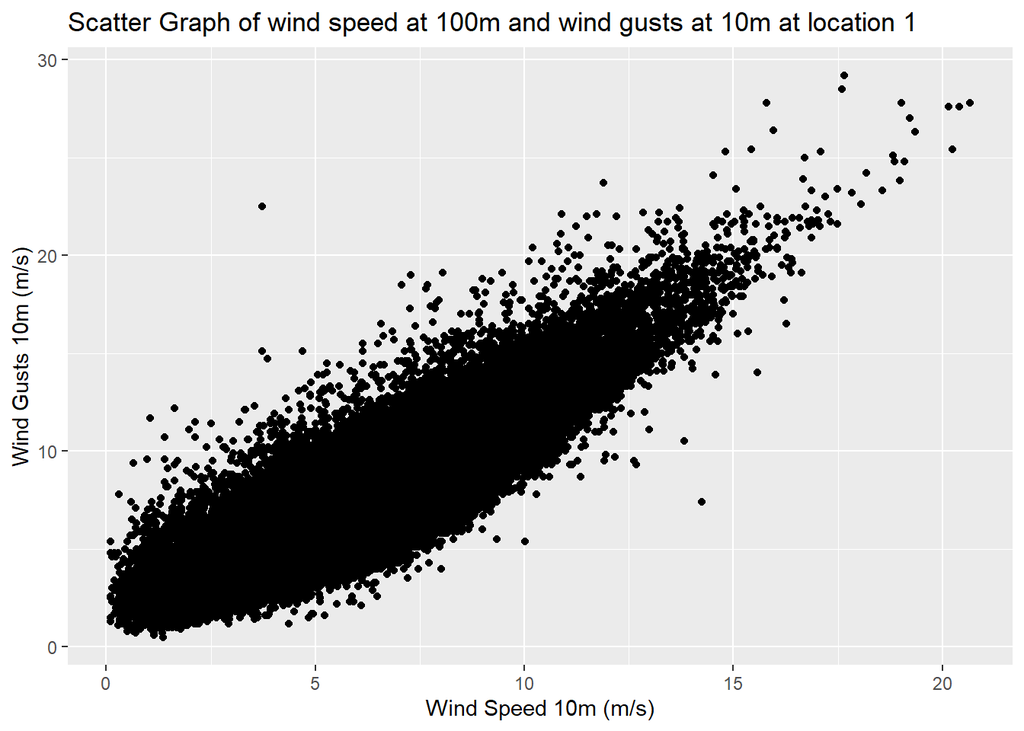

```r
ggplot(location1, aes(x = windspeed_100m, y = windgusts_10m)) +
  geom_point() +
  labs(title = 'Scatter Graph of wind speed at 100m and wind gusts at 10m at location 1', x = 'Wind Speed 10m (m/s)', y = 'Wind Gusts 10m (m/s)')
```

```r
wind_gusts_lm <- lm(location1$Power~location1$windgusts_10m)

summary(wind_gusts_lm)
```

```
##
## Call:
## lm(formula = location1$Power ~ location1$windgusts_10m)
##
## Residuals:
##      Min       1Q   Median       3Q      Max
## -1.16209 -0.15125 -0.01575  0.15284  0.72403
##
## Coefficients:
##                           Estimate Std. Error t value Pr(>|t|)
## (Intercept)             -0.0106567  0.0024722  -4.311 1.63e-05 ***
## location1$windgusts_10m  0.0535323  0.0002891 185.183  < 2e-16 ***
## ---
## Signif. codes:  0 '***' 0.001 '**' 0.01 '*' 0.05 '.' 0.1 ' ' 1
##
## Residual standard error: 0.2159 on 43798 degrees of freedom
## Multiple R-squared:  0.4391, Adjusted R-squared:  0.4391
## F-statistic: 3.429e+04 on 1 and 43798 DF,  p-value: < 2.2e-16
```

```r
summary(windspeed100_power_lm)
```

```
##
## Call:
## lm(formula = location1$Power ~ location1$windspeed_100m)
##
## Residuals:
##     Min      1Q  Median      3Q     Max
## -1.3024 -0.1226 -0.0082  0.1232  0.8501
##
## Coefficients:
##                            Estimate Std. Error t value Pr(>|t|)
## (Intercept)              -0.1200727  0.0021998  -54.58   <2e-16 ***
## location1$windspeed_100m  0.0836126  0.0003219  259.75   <2e-16 ***
## ---
## Signif. codes:  0 '***' 0.001 '**' 0.01 '*' 0.05 '.' 0.1 ' ' 1
##
## Residual standard error: 0.1809 on 43798 degrees of freedom
## Multiple R-squared:  0.6064, Adjusted R-squared:  0.6064
## F-statistic: 6.747e+04 on 1 and 43798 DF,  p-value: < 2.2e-16
```

Wind speed looks to be more correlated with Power based on the more significant p-value at the Intercept. Investigating wind direction 10m and wind direction 100m:

```r
cor.test(location1$sin_wd_10, location1$sin_wd_100)
```

```
##
##  Pearson's product-moment correlation
##
## data:  location1$sin_wd_10 and location1$sin_wd_100
## t = 1008.6, df = 43798, p-value < 2.2e-16
## alternative hypothesis: true correlation is not equal to 0
## 95 percent confidence interval:
##  0.9787543 0.9795275
## sample estimates:
##       cor
## 0.9791444
```

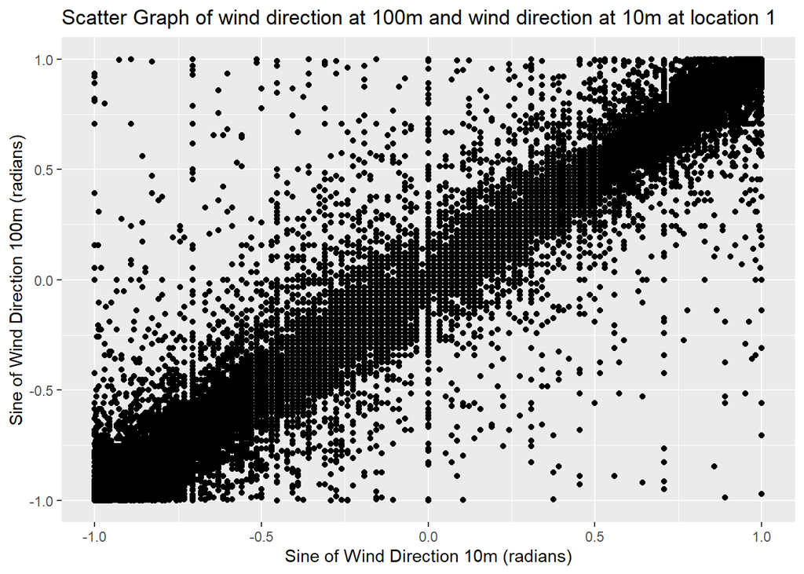

```r
ggplot(location1, aes(x = sin_wd_10 , y = sin_wd_100)) +
  geom_point() +
  labs(title = 'Scatter Graph of wind direction at 100m and wind direction at 10m at location 1', x = 'Sine of Wind Direction 10m (radians)', y = 'Sine of Wind Direction 100m (radians)')
```

```r
wind_direction10_lm <- lm(location1$Power~location1$sin_wd_10)
wind_direction100_lm <- lm(location1$Power~location1$sin_wd_100)

summary(wind_direction10_lm)
```

```
##
## Call:
## lm(formula = location1$Power ~ location1$sin_wd_10)
##
## Residuals:
##      Min       1Q   Median       3Q      Max
## -0.47636 -0.23594 -0.05429  0.23180  0.68536
##
## Coefficients:
##                      Estimate Std. Error t value Pr(>|t|)
## (Intercept)          0.381940   0.001426  267.81   <2e-16 ***
## location1$sin_wd_10 -0.094551   0.001947  -48.57   <2e-16 ***
## ---
## Signif. codes:  0 '***' 0.001 '**' 0.01 '*' 0.05 '.' 0.1 ' ' 1
##
## Residual standard error: 0.2809 on 43798 degrees of freedom
## Multiple R-squared:  0.05111,    Adjusted R-squared:  0.05109
## F-statistic:  2359 on 1 and 43798 DF,  p-value: < 2.2e-16
```

```r
summary(wind_direction100_lm)
```

```
##
## Call:
## lm(formula = location1$Power ~ location1$sin_wd_100)
##
## Residuals:
##      Min       1Q   Median       3Q      Max
## -0.48074 -0.23396 -0.05409  0.22930  0.69080
##
## Coefficients:
##                       Estimate Std. Error t value Pr(>|t|)
## (Intercept)           0.380605   0.001421  267.76   <2e-16 ***
## location1$sin_wd_100 -0.100155   0.001943  -51.55   <2e-16 ***
## ---
## Signif. codes:  0 '***' 0.001 '**' 0.01 '*' 0.05 '.' 0.1 ' ' 1
##
## Residual standard error: 0.28 on 43798 degrees of freedom
## Multiple R-squared:  0.05721,    Adjusted R-squared:  0.05719
## F-statistic:  2658 on 1 and 43798 DF,  p-value: < 2.2e-16
```

Both variables are similarly correlated with Power, so I will select wind direction at 100m and exclude wind direction at 10m.

Following this analysis, I have decided to select the following explanatory variables for modelling:

- temperature
- wind speed 100m
- wind direction 100m

# Preparing data for modelling

Excluding variables not selected for modelling:

```r
location1_final <- location1_numeric[c("temperature_2m", "windspeed_100m", "sin_wd_100", "Power")]
location2_final <- location2_numeric[c("temperature_2m", "windspeed_100m", "sin_wd_100", "Power")]
location3_final <- location3_numeric[c("temperature_2m", "windspeed_100m", "sin_wd_100", "Power")]
location4_final <- location4_numeric[c("temperature_2m", "windspeed_100m", "sin_wd_100", "Power")]
```

Verifying correct vars are present:

```r
head(location1_final)
```

```
##   temperature_2m windspeed_100m sin_wd_100  Power
## 1           28.5           1.26  0.3090170 0.1635
## 2           28.4           3.99  0.3746066 0.1424
## 3           26.8           2.78  0.5000000 0.1214
## 4           27.4           2.69  0.9659258 0.1003
## 5           27.3           4.43  0.9945219 0.0793
## 6           27.6           5.59  0.9848078 0.0778
```

```r
head(location2_final)
```

```
##   temperature_2m windspeed_100m sin_wd_100  Power
## 1           14.5           9.58  0.9510565 0.2574
## 2           14.5           9.23  0.9510565 0.2535
## 3           14.7           9.27  0.9612617 0.2497
## 4           14.7           9.08  0.9335804 0.2458
## 5           14.8           8.72  0.9063078 0.2419
## 6           14.7           8.83  0.8571673 0.2354
```

```r
head(location3_final)
```

```
##   temperature_2m windspeed_100m sin_wd_100  Power
## 1           29.7           8.46  0.7771460 0.3438
## 2           29.6           8.43  0.8290376 0.3954
## 3           29.8           9.18  0.8386706 0.4471
## 4           29.8           8.88  0.8090170 0.4988
## 5           30.2           8.36  0.7986355 0.5504
## 6           30.1           7.55  0.8191520 0.5731
```

```r
head(location4_final)
```

```
##   temperature_2m windspeed_100m sin_wd_100  Power
## 1           22.7           7.60  1.0000000 0.3047
## 2           22.0           7.92  0.9975641 0.3516
## 3           21.7           8.41  0.9986295 0.3985
## 4           21.7           8.26  0.9925462 0.4454
## 5           22.4           8.50  0.9998477 0.4922
## 6           22.8           8.12  0.9975641 0.4900
```

Writing csv in current directory:

```r
write.csv(location1_final, "location1_final.csv", row.names = FALSE)
write.csv(location2_final, "location2_final.csv", row.names = FALSE)
write.csv(location3_final, "location3_final.csv", row.names = FALSE)
write.csv(location4_final, "location4_final.csv", row.names = FALSE)
```